# EDA Findings

Elena Andrews, Derex Wangmang

April 21, 2021

## Initial Overview

The dataset we are using for our final project comes from the Local Area Arts Participation study from 1992. This study was funded by the National Endowment for the Arts (Research Division) and conducted by Abt Associates of Cambridge, MA. It contains information on whether and how often Americans attend and participate in various kinds of local art, including jazz concerts, ballet performances, etc. It also contains various demographic characteristics of the respondents. In collecting the data, Abt Associates randomly selected Americans from 12 localities via a random-digit-dialing sampling methodology and contacted them by phone for this survey.

In total, there are 5,040 total observations and 95 attributes. 72 of the characteristics are factored data while the other 23 are numeric data. The categorical characteristics generally involve whether the respondent attended or participated in local art as well as demographic data. The numerical features include the number of times the respondent attended that specific event as well as demographic data. There appear to be significant missingness within some characteristics of the data. These are due to three reasons: - The respondent did not know the answer. - The question did not apply to this respondent. - The respondent refused to answer the question.

The majority of NA values are due to the fact that the question did not apply. For instance, the columns with the most missing values, `bar5` and `bar4`, ask about the fourth and fifth reasons the respondent did not attend cultural and artistic events more often. However, the previous three questions, `bar1`, `bar2`, and `bar3`, ask the same question. `mags` asks what magazines the respondent read to learn about art events in the community, which would be dependent on whether the respondent read magazines and cited them as a source for learning about art events. For those that do not fall under that category, it is more likely that the respondent did not know the answer than a refusal to the question.

Below is an representation of the missingness.

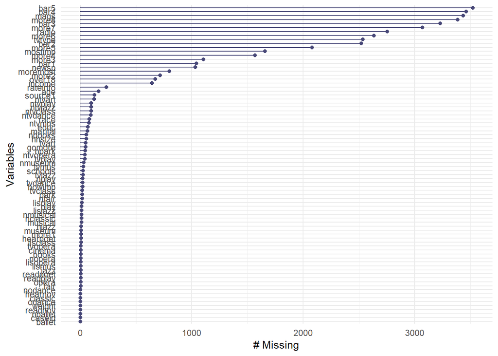

```r
library(tidyverse)
library(tidymodels)
library(naniar)
library(skimr)

set.seed(3206)
load(file = "data/processed/local_arts_data.Rda")

local_arts_split <- initial_split(data = local_arts_data, prop = 0.7, strata = income)
local_arts_train <- training(local_arts_split)

has_na <- function(x){
  any(is.na(x))
}

# Graph missingness
local_arts_train %>%
  # select only columns that have missing values
  select_if(has_na) %>%
  # graph using naniar
  gg_miss_var()
```

Given the amount of missingness in the data, it is expected that data will be imputed to replace missing values.

## Essential Findings

### Response Variable

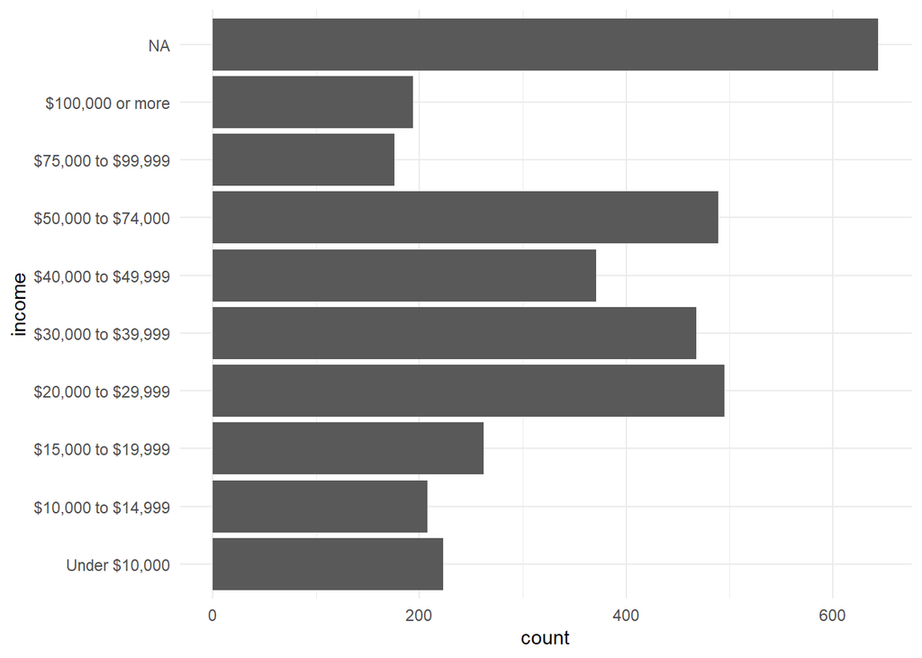

```r
local_arts_train %>%
  select(income) %>%
  ggplot(aes(x = income)) +
  geom_bar() +
  coord_flip() +
  theme_minimal()
```

### Predictor Variables

After performing some initial cleaning and processing of the dataset, there are 88 variables remaining, 87 of which may serve as predictor variables. Of these, the demographic variables seem as if they could provide valuable insight into the income of the participant, as income generally increases with age and education. Their participation in the arts may also correlate with their income, as high participation in the arts may signal more available time for leisure activities.

Some activities, such as reading books, are widely accessible than others, such as attending a live opera. As such, the expected predictor variables are in the table below.

```r
local_arts_train %>%
  select(starts_with("n"), -newsp, hhsize, over18, age, marital, educ, race, income, gender, weight)
```

```
## # A tibble: 3,530 x 27
##    njazz nclassic nopera nmusical nplay nballet nodance nmuseum nfair npark
##    <dbl>    <dbl>  <dbl>    <dbl> <dbl>   <dbl>   <dbl>   <dbl> <dbl> <dbl>
##  1     0        0      0        0     0       0       0       0     0     0
##  2     0        2      0        0     2       0       0       1     1     0
##  3     0        0      0        0     0       0       0       0     0     0
##  4     0        0      0        0     0       0       0       3     0     3
##  5     2        0      0        0     0       0       0       0     3     0
##  6    12        3      0        4     6       0       6       4     6     0
##  7     0        0      0        0     0       0       0       0     1     0
##  8     0        0      0        0     1       1       0       0     0     2
##  9     0        0      3        1     0       0       3       4     0    12
## 10     0        0      0        0     0       0      36       0     0     0
## # ... with 3,520 more rows, and 17 more variables: nbooks <dbl>, ntvjazz <dbl>,
## #   ntvclass <dbl>, ntvopera <dbl>, ntvmus <dbl>, ntvplay <dbl>,
## #   ntvdance <dbl>, ntvart <dbl>, hhsize <dbl>, over18 <dbl>, age <dbl>,
## #   marital <fct>, educ <fct>, race <fct>, income <fct>, gender <fct>,
## #   weight <dbl>
```

The proportion of people attending the arts seems like it follows the trend.

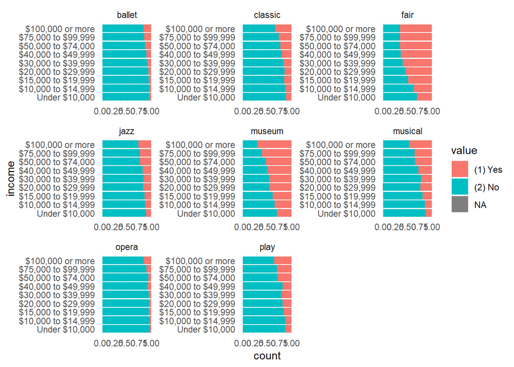

```r
local_arts_data %>%
  filter(museum != "(3) Don't know") %>%
  filter(!is.na(income)) %>%
  select(income, jazz, classic, opera, musical, play, ballet, museum, fair) %>%
  gather(-income, key = "var", value = "value") %>%
  ggplot(aes(x = income, fill = value)) +
  geom_bar(position = "fill") +
  coord_flip() +
  facet_wrap(~ var, scales = "free") +
  theme_minimal()
```

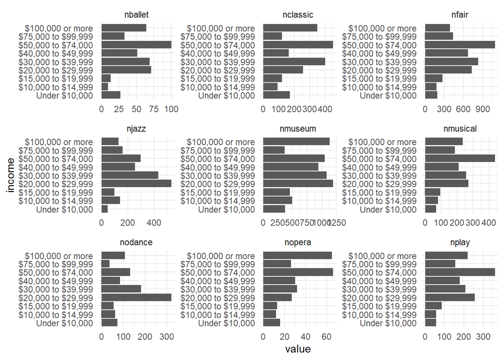

```r
local_arts_train %>%
  select(income, starts_with("n"), -newsp) %>%
  filter(!is.na(income)) %>%
  select(., 1:10) %>%
  gather(-income, key = "var", value = "value") %>%
  ggplot(aes(x = value, y = income)) +
  geom_col() +
  facet_wrap(~ var, scales = "free") +
  theme_minimal()
```

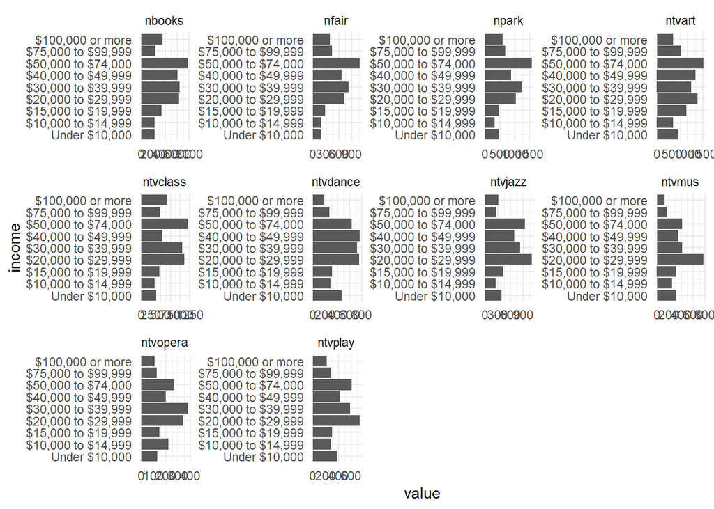

```r
local_arts_train %>%
  select(income, starts_with("n"), -newsp) %>%
  filter(!is.na(income)) %>%
  select(., 1, 10:19) %>%
  gather(-income, key = "var", value = "value") %>%
  ggplot(aes(x = value, y = income)) +
  geom_col() +
  facet_wrap(~ var, scales = "free") +
  theme_minimal()
```

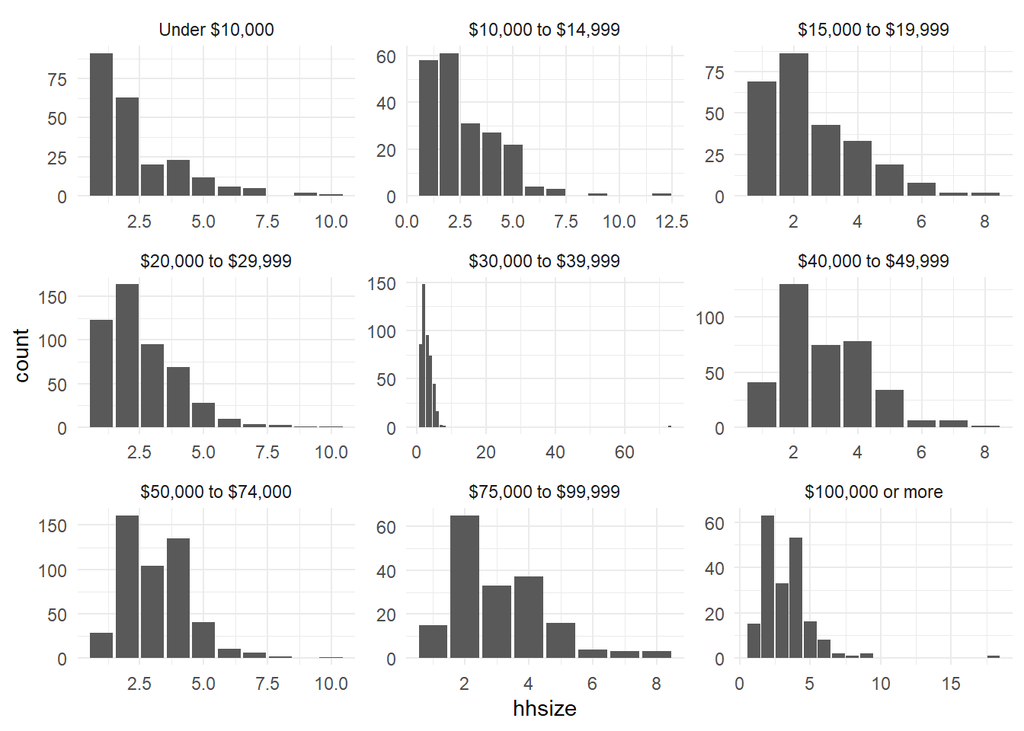

```r
local_arts_train %>%
  select(income, hhsize, over18, age, marital, educ, race, income, gender, weight) %>%
  filter(!is.na(income)) %>%
  select(income, hhsize) %>%
  ggplot(aes(hhsize)) +
  geom_bar() +
  facet_wrap(~ income, scales = "free") +
  theme_minimal()
```